# Reproducible Research - Coruse Project 1

Luis Espinosa

1/9/2020

Loading and processing the data.

```r
library(ggplot2)
library(knitr)
library(dplyr)
library(lattice)
activity<-read.csv("activity.csv")
```

1. What is mean total number of steps taken per day?

Calculate the total number of steps taken per day

```r
day_steps <- aggregate(steps~date, activity, sum)
```

Histogram of the total number of steps taken each day

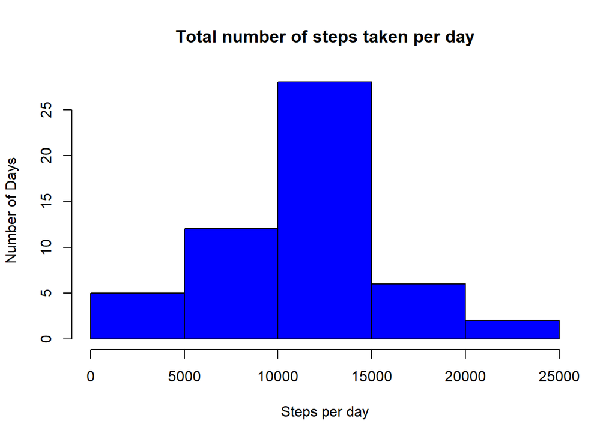

```r
hist(day_steps$steps, xlab="Steps per day", ylab="Number of Days",
     main="Total number of steps taken per day", col = "blue")
```

```r
dev.off()
```

Mean and median of the total number of steps taken per day

```r
mean_steps <- mean(day_steps$steps)
mean_steps
```

```
## [1] 10766.19
```

```r
median_steps <- median(day_steps$steps)
median_steps
```

```
## [1] 10765
```

2. What is the average daily activity pattern?

Time series plot of the 5-minute interval and the average number of steps taken, averaged across all days.

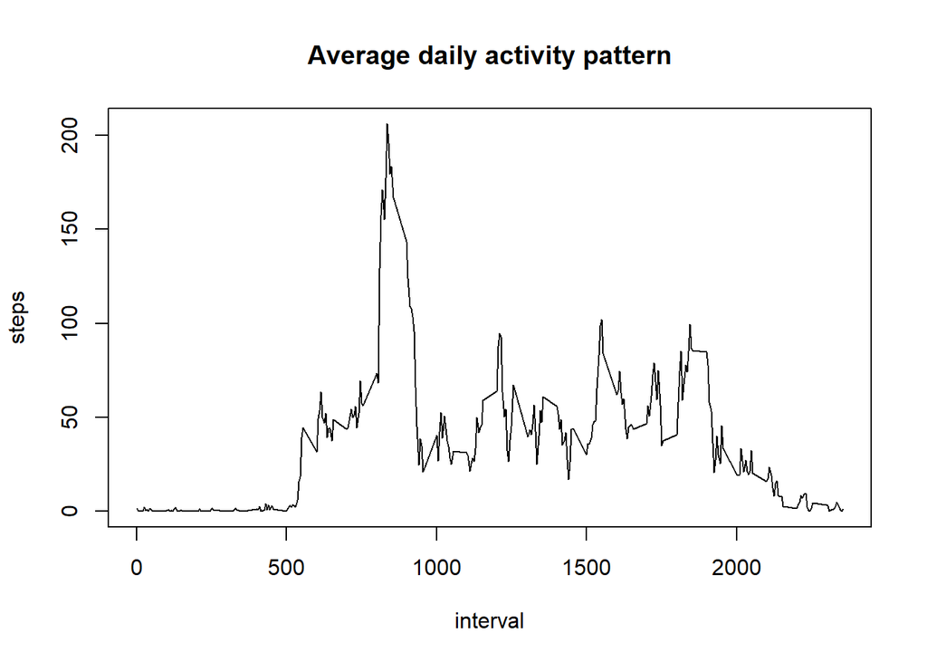

```r
average_steps <- aggregate(steps~interval, activity, mean)
with(average_steps, plot(interval, steps, type = "l",
                         main = "Average daily activity pattern"))
```

```r
dev.off()
```

5-minute interval with the maximum number of steps.

```r
max_5min <- average_steps[which.max(average_steps[,2]),1]
max_5min
```

```
## [1] 835
```

3. Imputing missing values

```r
missing_values <- is.na(activity[,1])
```

Devise a strategy for filling in all of the missing values in the dataset. In this case is the mean.

```r
mean_steps_int <- mean(average_steps$steps)
```

Create a new dataset that is equal to the original dataset but with the missing data filled in.

```r
new_activity <- activity
new_activity[missing_values, 1] <- mean_steps_int
new_day_steps <- aggregate(steps~date, new_activity, sum)
```

Make a histogram of the total number of steps taken each day and Calculate and report the mean and median total number of steps taken per day.

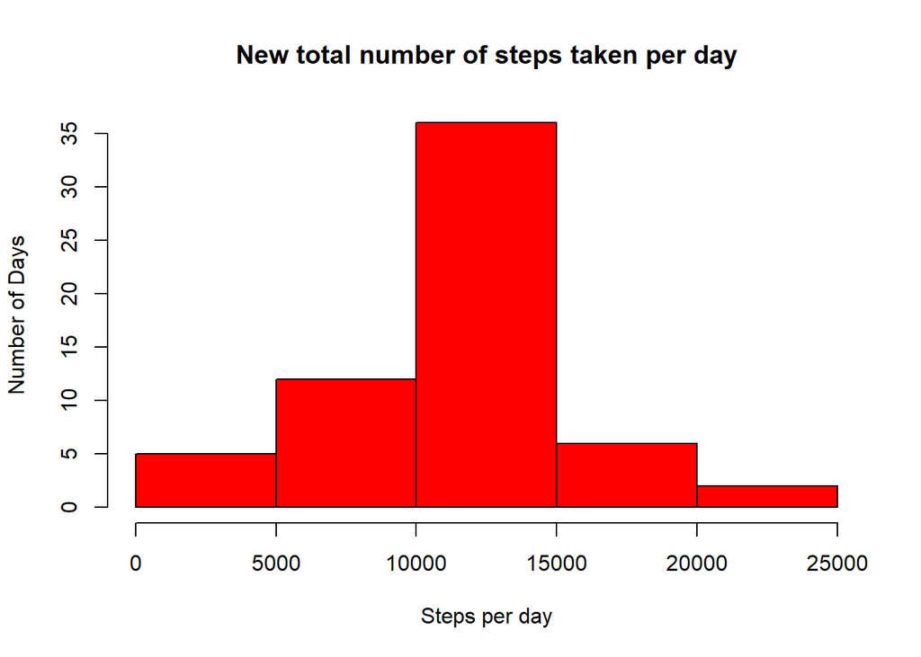

```r
hist(new_day_steps$steps, xlab="Steps per day", ylab="Number of Days",
     main="New total number of steps taken per day", col = "red")
```

```r
dev.off()
```

```r
new_mean_steps <- mean(new_day_steps$steps)
new_mean_steps
```

```
## [1] 10766.19
```

```r
new_median_steps <- median(new_day_steps$steps)
new_median_steps
```

```
## [1] 10766.19
```

```r
new_activity$date<-as.Date(new_activity$date)
final_activity <- new_activity%>%
  mutate(dayType = ifelse(weekdays(new_activity$date) == "Sábado" |
                            weekdays(new_activity$date) == "Domingo", "Weekend",
                          "Weekday"))
average_steps_int_day <- final_activity %>%
  group_by(dayType, interval) %>%
  summarise(av_byday = sum(steps))
```

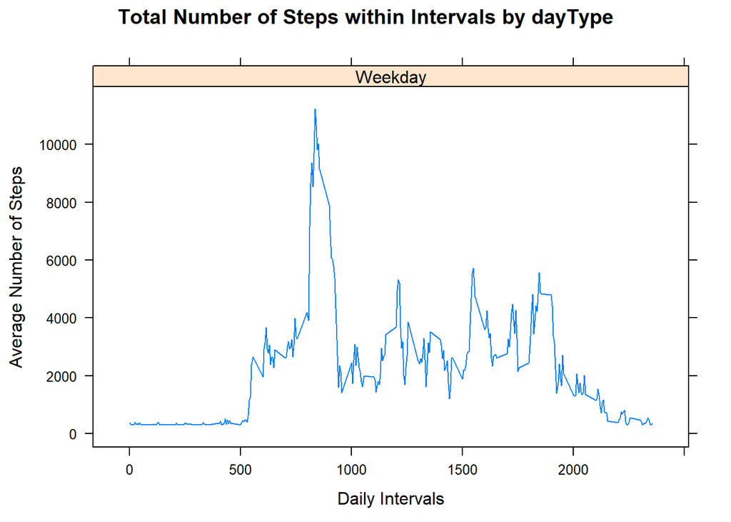

```r
with(average_steps_int_day,
     xyplot(av_byday ~ interval | dayType,
            type = "l",
            main = "Total Number of Steps within Intervals by dayType",
            xlab = "Daily Intervals",
            ylab = "Average Number of Steps"))
```

```r
dev.off()
```